# Reproducible Research Peer Assessment - 1

=================================================================================================================

This is an R Markdown document which serves as a report for Reproducible Research - Peer Assessment, Assignment-1.

## Loading and pre-processing data

Loading the required data into R and examining the data set.

```r
activity <- read.csv("activity.csv")
head(activity)
```

```
##   steps       date interval
## 1    NA 2012-10-01        0
## 2    NA 2012-10-01        5
## 3    NA 2012-10-01       10
## 4    NA 2012-10-01       15
## 5    NA 2012-10-01       20
## 6    NA 2012-10-01       25
```

## What is the mean total number of steps taken per day?

The total number of steps taken per day were calculated using the aggregate function and stored in a new variable, stepsTotal. The same was plotted on a graph and the corresponding mean and median were calculated using stepsTotal.

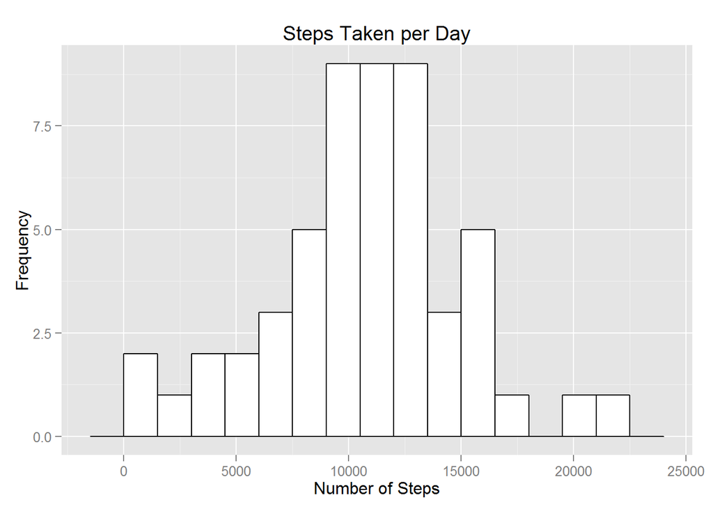

```r
library(ggplot2)

# Variable to store the total number of steps taken per day
stepsTotal <- aggregate(steps ~ date, data = activity, sum, na.action = na.pass)

# Plot of number of steps per day
ggplot(stepsTotal, aes(x = steps)) + geom_histogram(binwidth = 1500, color = "black", fill = "white") + labs(title = "Steps Taken per Day", x = "Number of Steps", y = "Frequency")
```

```r
mean(stepsTotal$steps, na.rm = TRUE) # Mean of steps/day
```

```
## [1] 10766.19
```

```r
median(stepsTotal$steps, na.rm = TRUE) # Median of steps/day
```

```
## [1] 10765
```

## What is the average daily activity pattern?

The average number of steps taken daily with respect to interval were calculated using the aggregate function and stored in a new variable, stepsAvg, and the same was plotted.

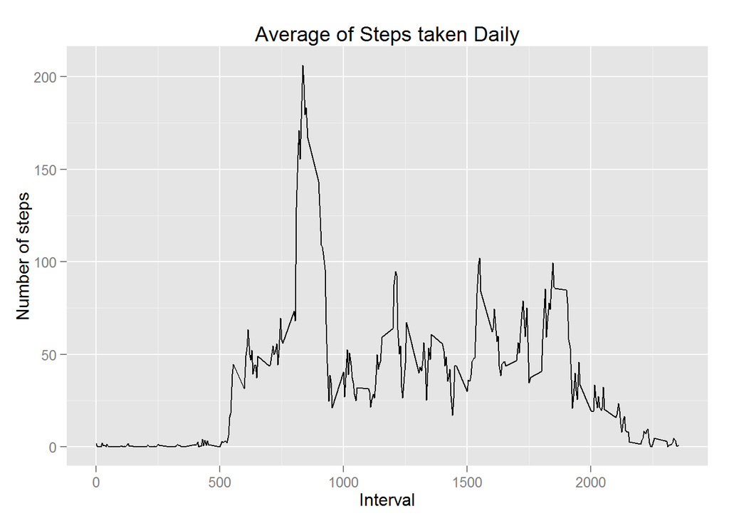

```r
# Variable to store the average number of steps taken daily by interval
stepsAvg <- aggregate(steps ~ interval, data = activity, mean, na.rm = TRUE)

# Plot of the average number of steps taken daily vs interval number
ggplot(stepsAvg, aes(x = interval, y = steps)) + geom_line() + labs(title = "Average of Steps taken Daily", x = "Interval", y = "Number of steps")
```

```r
# The 5 minute interval that contains the maximum number of steps
stepsAvg$interval[which.max(stepsAvg$steps)]
```

```
## [1] 835
```

## Imputing missing values

- Total number of rows with at least one NA value

```r
sum(complete.cases(activity) == FALSE)
```

```
## [1] 2304
```

- Strategy for filling in the missing values in the dataset: The mean value of steps for the corresponding interval has been used to replace the missing values in the dataset.
- Creating an imputed dataset

```r
library(plyr)

# Creating an imputed dataset using the mean values of steps from their corresponding intervals.
activity.impute <- adply(activity, 1, function(x) if (is.na(x$steps)){
    x$steps = round(stepsAvg[stepsAvg$interval == x$interval, 2])
    x
} else {
    x
})
```

- Histogram of imputed total number of steps per day, mean, median and comparision of the new result with the previous result.

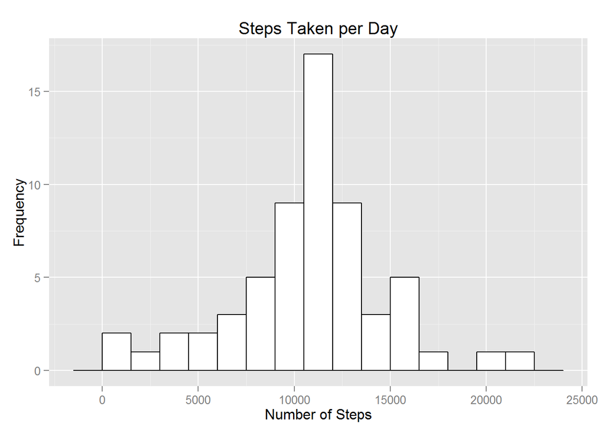

```r
# Variable to store the total imputed number of steps taken per day
stepsTotal.impute <- aggregate(steps ~ date, data = activity.impute, sum)

# Plot of the imputed number of steps per day
ggplot(stepsTotal.impute, aes(x = steps)) + geom_histogram(binwidth = 1500, color = "black", fill = "white") + labs(title = "Steps Taken per Day", x = "Number of Steps", y = "Frequency")
```

```r
mean(stepsTotal.impute$steps) # Mean of imputed steps/day
```

```
## [1] 10765.64
```

```r
median(stepsTotal.impute$steps) # Median of imputed steps/day
```

```
## [1] 10762
```

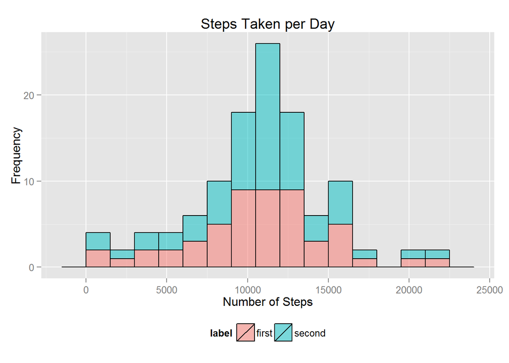

```r
# Combining the variables for steps/day of the original and imputed datasets into a new variable and assigning labels for identification
stepsTotal.all <- rbind(stepsTotal, stepsTotal.impute)
stepsTotal.all$label[1:61] = "first"
stepsTotal.all$label[62:122] = "second"
levels(stepsTotal.all$label) <- c("With NA", "Without NA")

# Plotting a comparative histogram to examine the differences
ggplot(stepsTotal.all, aes(x = steps, fill = label)) + geom_histogram(binwidth = 1500, colour = "black", alpha = 0.5) + labs(title = "Steps Taken per Day", x = "Number of Steps", y = "Frequency") + theme(legend.position = "bottom")
```

## Are there differences in activity patterns between weekdays and weekends?

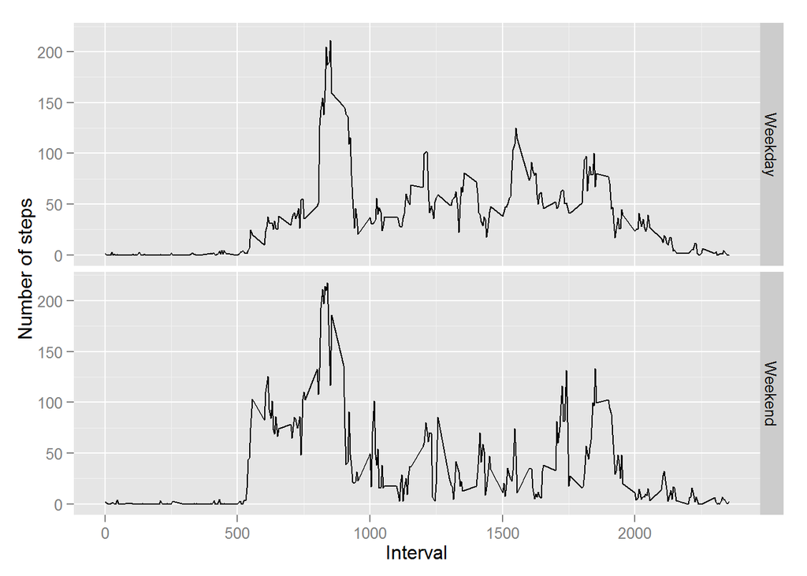

```r
# Converting the class of date variable to 'Date'
class(activity.impute$date) = "Date"

# Creating separate subset for weekends and weekdays
activity.impute.weekend <- subset(activity.impute, weekdays(date) %in% c("Saturday", "Sunday"))
activity.impute.weekday <- subset(activity.impute, !weekdays(date) %in% c("Saturday", "Sunday"))

# Creating new variables to store the corresponding aggregates
stepsWeekend <- aggregate(steps ~ interval, data = activity.impute.weekend, mean)
stepsWeekday <- aggregate(steps ~ interval, data = activity.impute.weekday, mean)

# Creating labels for identification and combining the two variables
stepsWeekday <- cbind(stepsWeekday, day = "Weekday")
stepsWeekend <- cbind(stepsWeekend, day = "Weekend")
activity.impute.week <- rbind(stepsWeekday, stepsWeekend)
levels(activity.impute.week$day) <- c("Weekday", "Weekend")

# Plot for activity patterns between weekdays and weekends
ggplot(activity.impute.week, aes(x = interval, y = steps)) + geom_line() + facet_grid(day ~ .) + labs(x = "Interval", y = "Number of steps")
```